# R: Soil Data from the Central Sierra Nevada Region of California

| ca630 {aqp} | R Documentation |
| --- | --- |

## Soil Data from the Central Sierra Nevada Region of California

### Description

Site and laboratory data from soils sampled in the central Sierra Nevada Region of California.

### Usage

```
data(ca630)
```

### Format

List containing:

$site : A data frame containing site information.

**`user_site_id`**

national user site id

**`mlra`**

the MLRA

**`county`**

the county

**`ssa`**

soil survey area

**`lon`**

longitude, WGS84

**`lat`**

latitude, WGS84

**`pedon_key`**

national soil profile id

**`user_pedon_id`**

local soil profile id

**`cntrl_depth_to_top`**

control section top depth (cm)

**`cntrl_depth_to_bot`**

control section bottom depth (cm)

**`sampled_taxon_name`**

soil series name

$lab : A data frame containing horizon information.

**`pedon_key`**

national soil profile id

**`layer_key`**

national horizon id

**`layer_sequence`**

horizon sequence number

**`hzn_top`**

horizon top (cm)

**`hzn_bot`**

horizon bottom (cm)

**`hzn_desgn`**

horizon name

**`texture_description`**

USDA soil texture

**`nh4_sum_bases`**

sum of bases extracted by ammonium acetate (pH 7)

**`ex_acid`**

exchangeable acidity [method ?]

**`CEC8.2`**

cation exchange capacity by sum of cations method (pH 8.2)

**`CEC7`**

cation exchange capacity by ammonium acetate (pH 7)

**`bs_8.2`**

base saturation by sum of cations method (pH 8.2)

**`bs_7`**

base saturation by ammonium acetate (pH 7)

### Source

http://ssldata.nrcs.usda.gov/

### Examples

```r
library(plyr)
library(lattice)
library(Hmisc)
library(maps)
library(sp)

# check the data out:
data(ca630)
str(ca630)
```

```
## List of 2
##  $ site:'data.frame':    137 obs. of  11 variables:
##   ..$ user_site_id      : chr [1:137] "90CA009101" "90CA009102" "90CA009103" "90CA009104" ...
##   ..$ mlra              : chr [1:137] "22" "22" "22" "22" ...
##   ..$ county            : chr [1:137] "CA009" "CA009" "CA009" "CA009" ...
##   ..$ ssa               : chr [1:137] "CA731" "CA731" "CA731" "CA731" ...
##   ..$ lon               : num [1:137] -120 -120 -120 -120 -120 ...
##   ..$ lat               : num [1:137] 38.4 38.4 38.4 38.4 38.3 ...
##   ..$ pedon_key         : chr [1:137] "91P0709" "91P0710" "91P0711" "91P0712" ...
##   ..$ user_pedon_id     : chr [1:137] "90CA009101" "90CA009102" "90CA009103" "90CA009104" ...
##   ..$ cntrl_depth_to_top: int [1:137] NA 25 NA 0 25 NA 25 25 0 28 ...
##   ..$ cntrl_depth_to_bot: int [1:137] NA 100 NA 30 100 NA 97 100 30 78 ...
##   ..$ sampled_taxon_name: chr [1:137] "Windy" "Tallac" "Gerle" "Nd" ...
##  $ lab :'data.frame':    571 obs. of  13 variables:
##   ..$ pedon_key          : chr [1:571] "91P0709" "91P0709" "91P0709" "91P0709" ...
##   ..$ layer_key          : chr [1:571] "91P04048" "91P04049" "91P04050" "91P04051" ...
##   ..$ layer_sequence     : int [1:571] 1 2 3 4 1 2 3 4 1 2 ...
##   ..$ hzn_top            : int [1:571] 0 30 79 119 0 25 46 71 0 25 ...
##   ..$ hzn_bot            : int [1:571] 30 79 119 218 25 46 71 107 25 58 ...
##   ..$ hzn_desgn          : chr [1:571] "A" "Bw1" "Bw2" "C" ...
##   ..$ texture_description: chr [1:571] "Sandy loam" "Sandy loam" "Fine sandy loam" "Fine sandy loam" ...
##   ..$ nh4_sum_bases      : num [1:571] 9.9 1.3 0.9 0.8 10.1 1.4 0.8 0.2 1.7 0.5 ...
##   ..$ ex_acid            : num [1:571] 21.9 18.8 13.7 12.2 11.3 18.6 18.6 12 11.6 9.3 ...
##   ..$ CEC8.2             : num [1:571] 31.8 20.1 14.6 13 21.4 20 19.4 12.2 13.3 9.8 ...
##   ..$ CEC7               : num [1:571] 25.3 13.2 10.8 9 16.7 14.1 11.6 6.5 14.9 9.7 ...
##   ..$ bs_8.2             : int [1:571] 31 6 6 6 47 7 4 2 13 5 ...
##   ..$ bs_7               : int [1:571] 39 10 8 9 60 10 7 3 11 5 ...
```

```r
# note that pedon_key is the link between the two tables

# make a copy of the horizon data
ca <- ca630$lab

# promote to a SoilProfileCollection class object
depths(ca) <- pedon_key ~ hzn_top + hzn_bot

# add site data, based on pedon_key
site(ca) <- ca630$site

# ID data missing coordinates: '|' is a logical OR
(missing.coords.idx <- which(is.na(ca$lat) | is.na(ca$lon)))
```

```
## [1] 48 56
```

```r
# remove missing coordinates by safely subsetting
if(length(missing.coords.idx) > 0)
    ca <- ca[-missing.coords.idx, ]

# register spatial data
coordinates(ca) <- ~ lon + lat

# assign a coordinate reference system
proj4string(ca) <- '+proj=longlat +datum=NAD83'

# check the result
print(ca)
```

```
## Object of class SoilProfileCollection
## Number of profiles: 113
## Depth range: 29-260 cm
##
## Horizon attributes:
##     pedon_key layer_key layer_sequence hzn_top hzn_bot hzn_desgn
## 451   00P0780  00P04900              1       0       2         A
## 452   00P0780  00P04901              2       2      15       Bw1
## 453   00P0780  00P04902              3      15      30       Bw2
## 454   00P0780  00P04903              4      30      45        Cd
## 455   00P0781  00P04904              1       0      14         A
## 456   00P0781  00P04905              2      14      38       Bt1
##      texture_description nh4_sum_bases ex_acid CEC8.2 CEC7 bs_8.2 bs_7
## 451 Loamy very fine sand           1.2     8.7    9.9  9.8     12   12
## 452      Fine sandy loam           0.4    11.2   11.6  5.7      3    7
## 453      Fine sandy loam           0.4     9.2    9.6  4.0      4   10
## 454      Fine sandy loam           0.4     3.9    4.3  1.7      9   24
## 455      Fine sandy loam           2.0    12.0   14.0  8.2     14   24
## 456      Fine sandy loam           1.1    20.8   21.9 11.7      5    9
##
## Sampling site attributes:
##   pedon_key user_site_id mlra county   ssa user_pedon_id
## 1   00P0780   00CA109001   22  CA109 CA790    00CA109001
## 2   00P0781   00CA109002   22  CA109 CA790    00CA109002
## 3   00P0783   00CA109004   22  CA109 CA790    00CA109004
## 4   00P0784   00CA109005   22  CA109 CA790    00CA109005
## 5   00P0785   00CA109006   22  CA109 CA790    00CA109006
## 6   00P0786   00CA109007   22  CA109 CA790    00CA109007
##   cntrl_depth_to_top cntrl_depth_to_bot sampled_taxon_name
## 1                 25                100          (unnamed)
## 2                 14                 64          (unnamed)
## 3                 25                100          (unnamed)
## 4                 25                100          (unnamed)
## 5                 25                100          (unnamed)
## 6                 25                100          (unnamed)
##
## Spatial Data:
##            min        max
## lon -120.71503 -119.15709
## lat   37.75437   38.45706
## [1] "+proj=longlat +datum=NAD83"
```

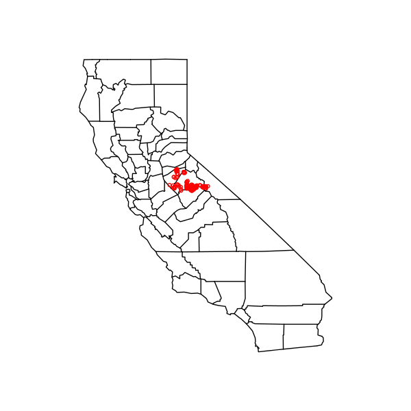

```r
# map the data (several ways to do this, here is a simple way)
map(database='county', region='california')
points(coordinates(ca), col='red', cex=0.5)
```

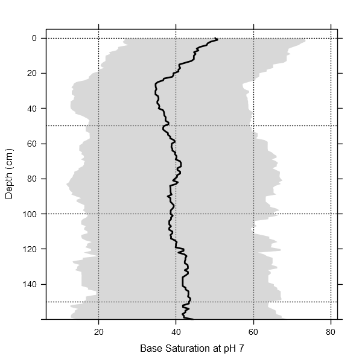

```r
# aggregate %BS 7 for all profiles into 1 cm slices
a <- slab(ca, fm= ~ bs_7)

# plot median & IQR by 1 cm slice
xyplot(
top ~ p.q50, data=a, lower=a$p.q25, upper=a$p.q75,
ylim=c(160,-5), alpha=0.5, scales=list(alternating=1, y=list(tick.num=7)),
panel=panel.depth_function, prepanel=prepanel.depth_function,
ylab='Depth (cm)', xlab='Base Saturation at pH 7',
par.settings=list(superpose.line=list(col='black', lwd=2))
)
```

[figure not shown]

```r
# aggregate %BS at pH 8.2 for all profiles by MLRA, along 1 cm slices
# note that mlra is stored in @site
a <- slab(ca, mlra ~ bs_8.2)

# keep only MLRA 18 and 22
a <- subset(a, subset=mlra %in% c('18', '22'))

# plot median & IQR by 1 cm slice, using different colors for each MLRA
xyplot(
top ~ p.q50, groups=mlra , data=a, lower=a$p.q25, upper=a$p.q75,
ylim=c(160,-5), alpha=0.5, scales=list(y=list(tick.num=7, alternating=3), x=list(alternating=1)),
panel=panel.depth_function, prepanel=prepanel.depth_function,
ylab='Depth (cm)', xlab='Base Saturation at pH 8.2',
par.settings=list(superpose.line=list(col=c('black','blue'), lty=c(1,2), lwd=2)),
auto.key=list(columns=2, title='MLRA', points=FALSE, lines=TRUE)
)
```

```r
# safely compute hz-thickness weighted mean CEC (pH 7)
# using data.frame objects
head(lab.agg.cec_7 <- ddply(ca630$lab, .(pedon_key),
.fun=summarise, CEC_7=wtd.mean(bs_7, weights=hzn_bot-hzn_top)))
```

```
##   pedon_key     CEC_7
## 1   00P0780 13.888889
## 2   00P0781 11.191489
## 3   00P0783 19.254545
## 4   00P0784 29.825000
## 5   00P0785  9.917722
## 6   00P0786 11.514286
```

```r
# extract a SPDF with horizon data along a slice at 25 cm
s.25 <- slice(ca, fm=25 ~ bs_7 + CEC7 + ex_acid)
```

```
## result is a SpatialPointsDataFrame object
```

```r
spplot(s.25, zcol=c('bs_7','CEC7','ex_acid'))

# note that the ordering is preserved:
all.equal(s.25$pedon_key, profile_id(ca))
```

[output not shown]

```
## [1] TRUE
```

```r
# extract a data.frame with horizon data at 10, 20, and 50 cm
s.multiple <- slice(ca, fm=c(10,20,50) ~ bs_7 + CEC7 + ex_acid)

# Extract the 2nd horizon from all profiles as SPDF
ca.2 <- ca[, 2]
```

```
## result is a SpatialPointsDataFrame object
```

```r
# subset profiles 1 through 10
ca.1.to.10 <- ca[1:10, ]

# basic plot method: profile plot
plot(ca.1.to.10, name='hzn_desgn')
```

[output not shown]

[Package *aqp* version 1.7-11 Index]